# Analyais on external debt and currency crisis in Emerging markets

April.29 2019

## Problem statement and Background

## Problem statement and Background

Frequent currency crisis in EMEs: Why so vulnerable?

- a high level of external debt
- external shocks
- politicial instability
- GDP level

## Problem statement and Background

- What factors strengthen or weaken the link between external debt and currency crisis in EMEs?
- How to predict the possibility of a currency crisis happening in the future?
- Policy guidance for central bank policymakers in emerging markets

Testable hypothesis:

- EMEs with high external debt are more prone to currency crisis risks

## Approach

## Approach

Variables:

- Dependent variable: possibility of currency crisis (a nominal depreciation of 15% within a year)
- Independent variable: external debt/GNI
- Control variable: GDP per capita, level of democracy, US 3-month treasury yield, foreign reserves/total external debt

Data access:

- the World Bank Open Data
- the International Monetary Fund (IMF) Open Data
- the Polity IV Project conducted by the Center for Systemic Peace

## Methods

## Methods

Data visualizations

- The connection between currency crisis and external debt
- The connection between currency crisis and control variables

Logit model

- Model the probability of a currency crisis happening given all variables
- (external debt/GNI; GDP per capita, level of democracy, US 3-month treasury yield, foreign reserves/total external debt)

Machine learning

- Predict the classification
- Several models (K nearest neighbours, CART, and Random Forest)

## Result

## Result: data visualizations

[figure not shown]

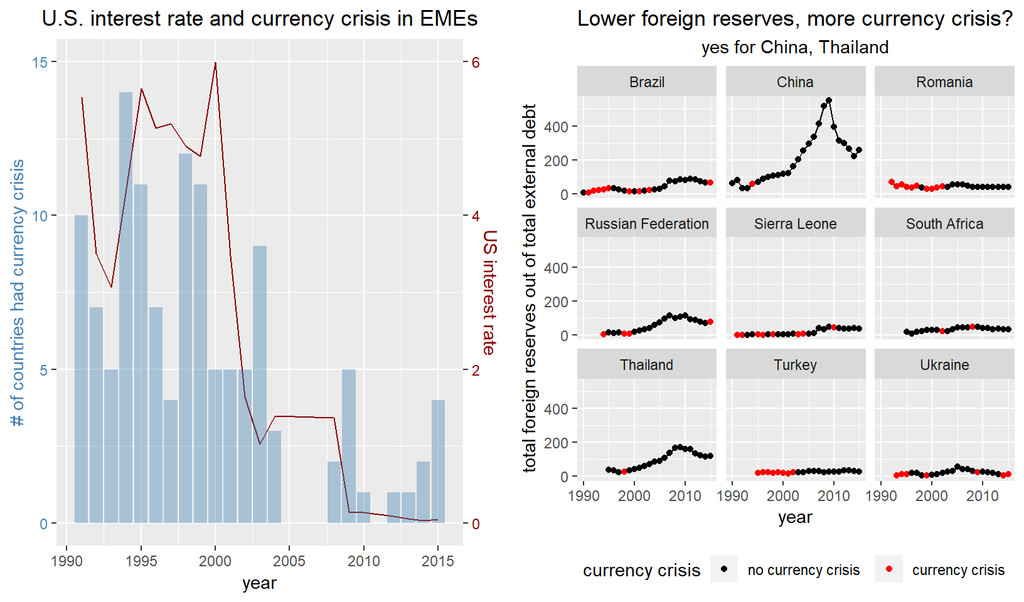

## Result: Logit model

This supports our main hypothesis that countries who have borrowed excessively in foreign currency are more prone to currency crisis risks.

a negative correlation between the ratio of foreign reserves to a country’s total external debt in the previous year and the dependent variable

also a negative correlation between GDP per capita in the previous year and the probability of a currency crisis happening

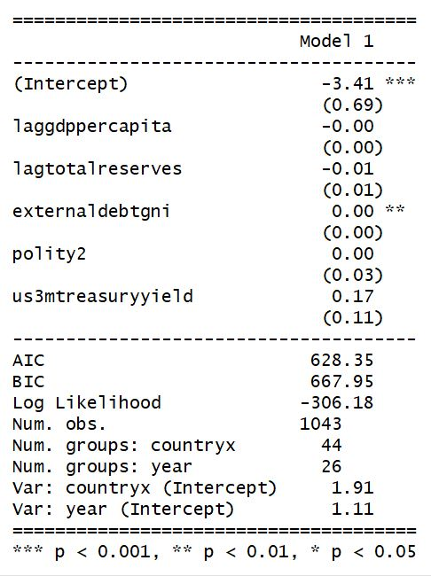

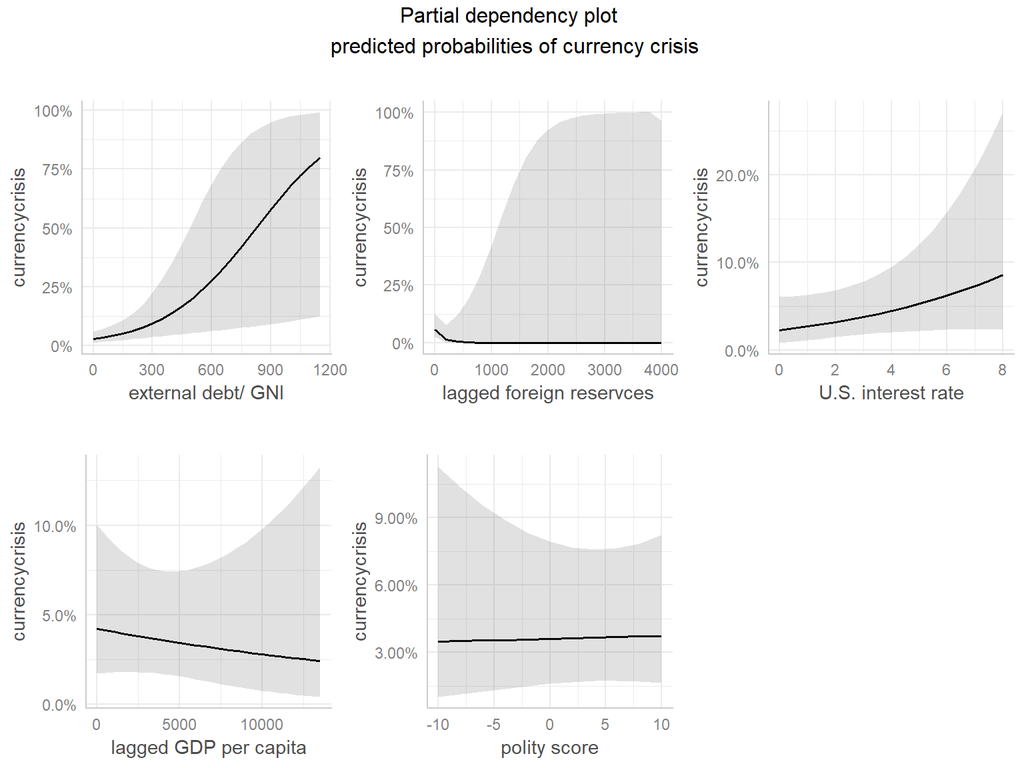

## Result: Machine learning

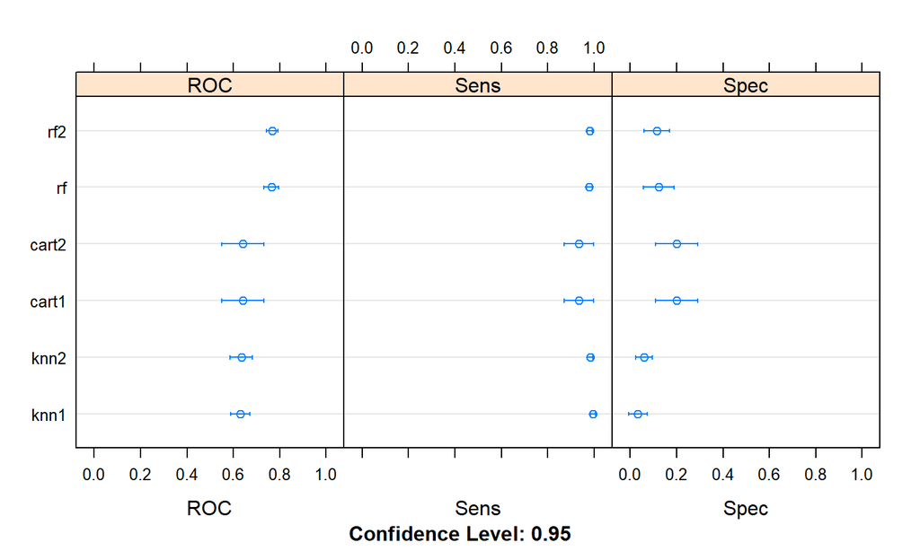

## Predictive performance for mod2_rf

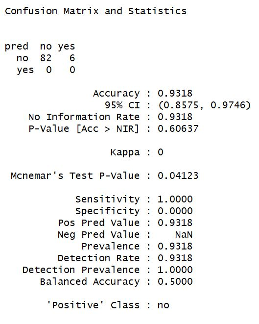

## Most important variables

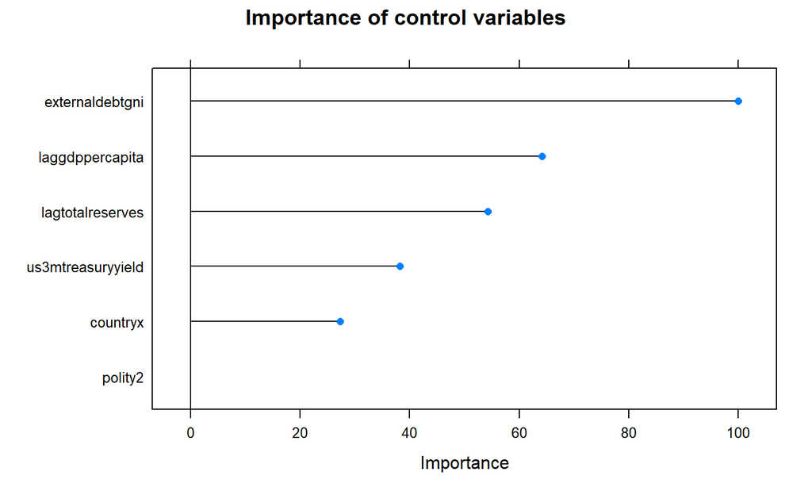

## Conclusion

## Lessons learned

- EMEs should control external debt level
- Stock foreign reserves
- Boost GDP
- Monitor U.S. interest rate volatility

## Next steps

- Find a better proxy for political instability
- More variables to include: economic structure & exchange rate regime
- Expand the time rage